# ME323 - Introdução aos Modelos Probabilísticos

## Distribuição Normal

## Distribuição Normal

Dizemos que uma v.a. \(X\) possui distribuição normal com parâmetros \(\mu\) e \(\sigma^{2}\), \(\mu \in \mathbb{R}\) e \(\sigma^{2}>0\), se a f.d.p. \(f_{X}\) é dada por:

\[f_{X}(x) = \frac{1}{\sqrt{2\pi\sigma^{2}}} \exp \left[-\frac{(x-\mu)^{2}}{2\sigma^{2}}\right], \qquad -\infty < x < \infty\]

**Notação:** \(X\sim N(\mu,\sigma^{2})\)

Distribuição mais importante da Estatística. Também conhecida como distribuição Gaussiana.

A esperança e variância de uma v.a. \(X \sim N(\mu,\sigma^{2})\) são:

\[\mathbb E(X)=\mu \qquad \mbox{e} \qquad Var(X)=\sigma^2\]

## Distribuição Normal - Esperança e Variância

**Esperança:** \[\mathbb E(X) = \int_{-\infty}^{\infty} x \frac{1}{\sqrt{2\pi\sigma^{2}}} \exp\left[-\frac{(x-\mu)^{2}}{2\sigma^{2}}\right]dx=\mu\]

**Variância** \[ \begin{aligned} Var(X) & = \mathbb E([X - \mathbb E(X)]^{2}) \\ & = \int_{-\infty}^{\infty}(x-\mu)^{2}\frac{1}{\sqrt{2\pi\sigma^{2}}} \exp\left[-\frac{(x-\mu)^{2}}{2\sigma^{2}}\right]dx \\ &=\sigma^{2} \end{aligned} \]

## Distribuição Normal

Gráfico da função de densidade de probabilidade de uma v.a. \(X \sim N(\mu,\sigma^{2})\)

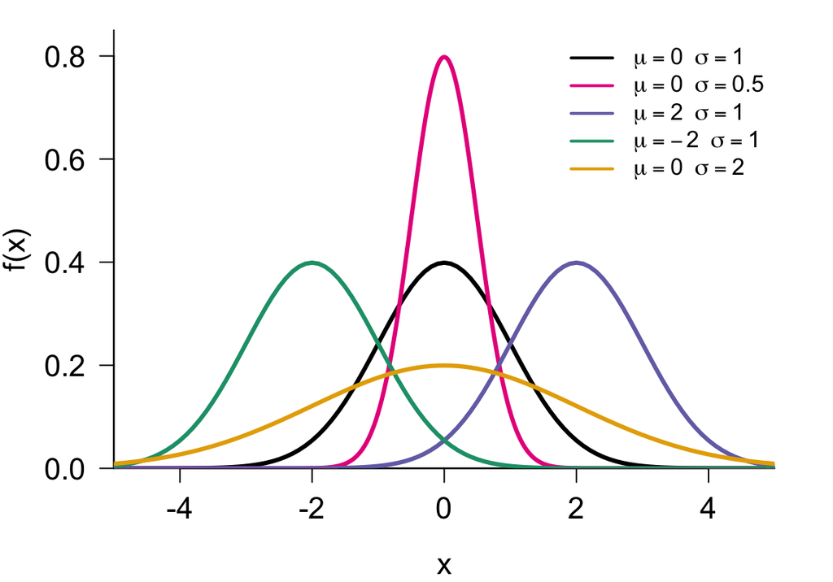

**Função Densidade:** "Forma de sino", centrada em \(\mu\) e escala controlada por \(\sigma^2\)

## Exemplo: OkCupid

OkCupid é uma rede social para relacionamentos.

> Usuários devem colocar características pessoais como, por exemplo, altura.

> Será que são sinceros?

[figure not shown]

## Exemplo: OkCupid

Comparação da distribuição das alturas da população adulta norte-americana e a distribuição das alturas dos usuários do site:

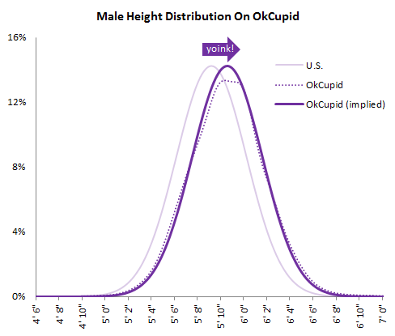

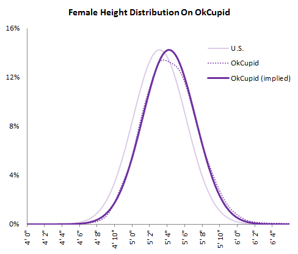

*Fonte: http://blog.okcupid.com/index.php/the-biggest-lies-in-online-dating/*

## Exemplo: OkCupid

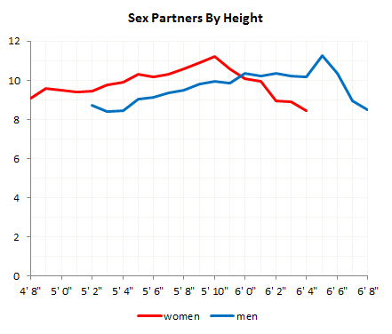

*Fonte: http://blog.okcupid.com/index.php/the-biggest-lies-in-online-dating/*

## Distribuição Normal Padrão

**Propriedade**: Se \(X \sim N(\mu, \sigma^{2})\), então \[Z=\frac{X-\mu}{\sigma} \sim N(0,1)\]

Dizemos que \(Z\) tem distribuição **Normal Padrão** e sua densidade se reduz a: \[\phi(z)=\frac{1}{\sqrt{2\pi}}e^{-z^2/2}, \qquad -\infty < z < \infty\]

A f.d.a. de uma Normal padrão, que denotaremos por \(\Phi\), é: \[\Phi(t)=P(Z\leq t)=\int_{-\infty}^{t}\frac{1}{\sqrt{2\pi}}e^{-z^2/2}dz\]

## Distribuição Normal Padrão

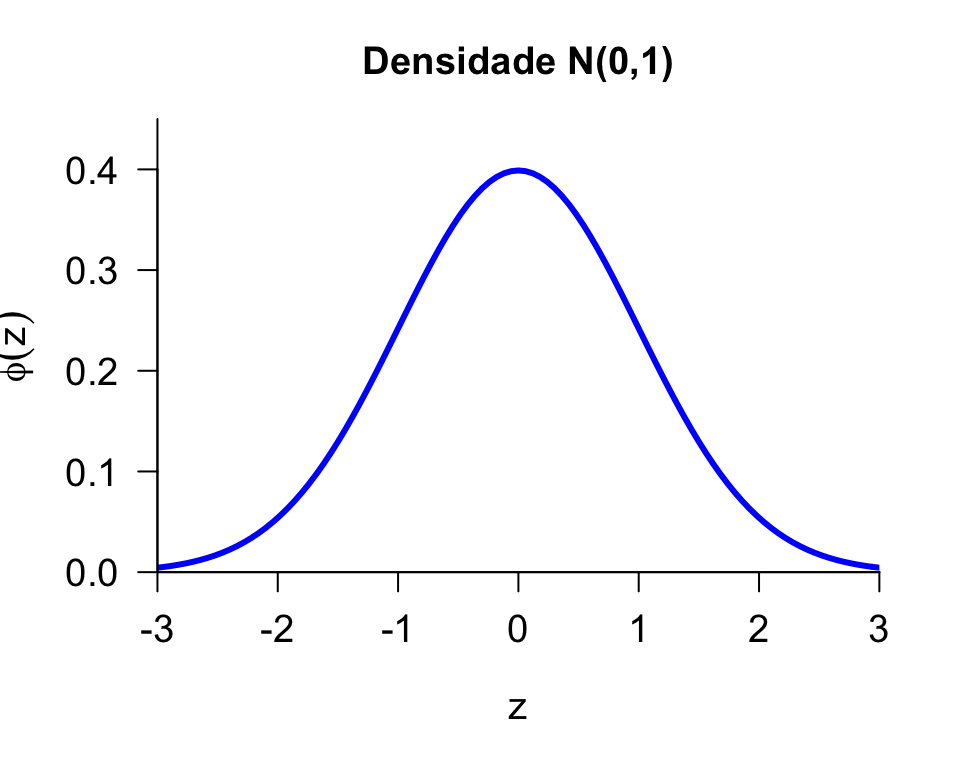

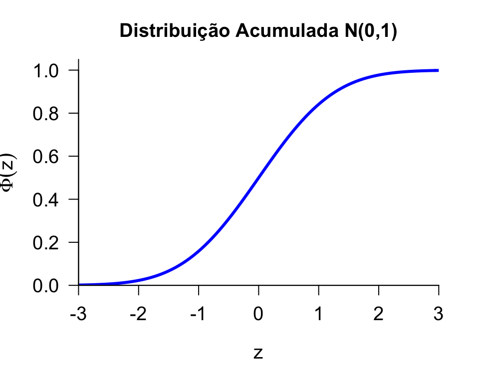

## Exemplo: SAT e ACT

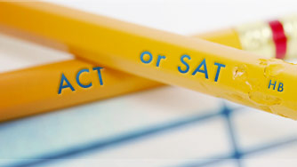

Uma universidade americana recebeu inscrição de dois alunos (Pam e Jim) com os respectivos históricos escolares. No entanto, Pam realizou o SAT e tirou 1800, enquanto que o Jim fez o ACT e tirou 24. Como a universidade pode comparar os dois alunos, baseando-se nesses testes?

> Precisamos avaliar quão melhor (ou pior) a Pam foi em relação aos demais alunos que realizaram o SAT.

> Precisamos avaliar quão melhor (ou pior) o Jim foi em relação aos demais alunos que realizaram o ACT.

## Exemplo: SAT e ACT

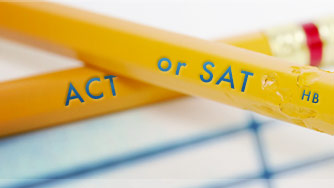

> A universidade tem acesso à média (1500) e ao desvio-padrão (300) das notas de todos os alunos que realizaram o SAT juntamente com a Pam.

> A universidade tem acesso à média (21) e ao desvio-padrão (5) das notas de todos os alunos que realizaram o ACT juntamente com a Jim.

> Assumindo que as notas dos dois testes seguem uma distribuição normal:

Seja \(X\) uma v.a. representando a nota no SAT: \(X\sim N(\mu=1500,\sigma=300)\).

Seja \(Y\) uma v.a. representando a nota no ACT: \(X\sim N(\mu=21,\sigma=5)\).

## Exemplo: SAT e ACT

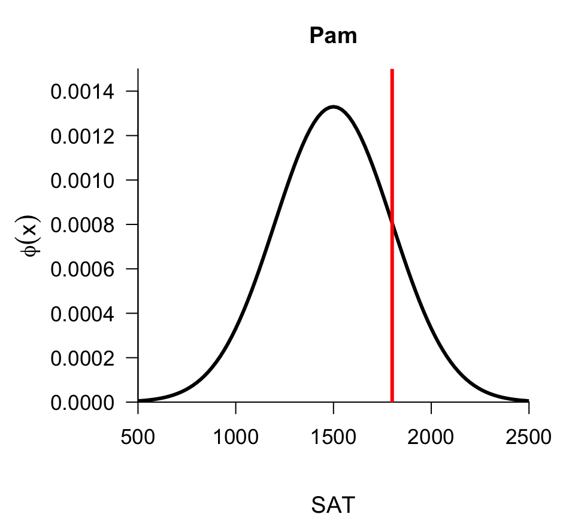

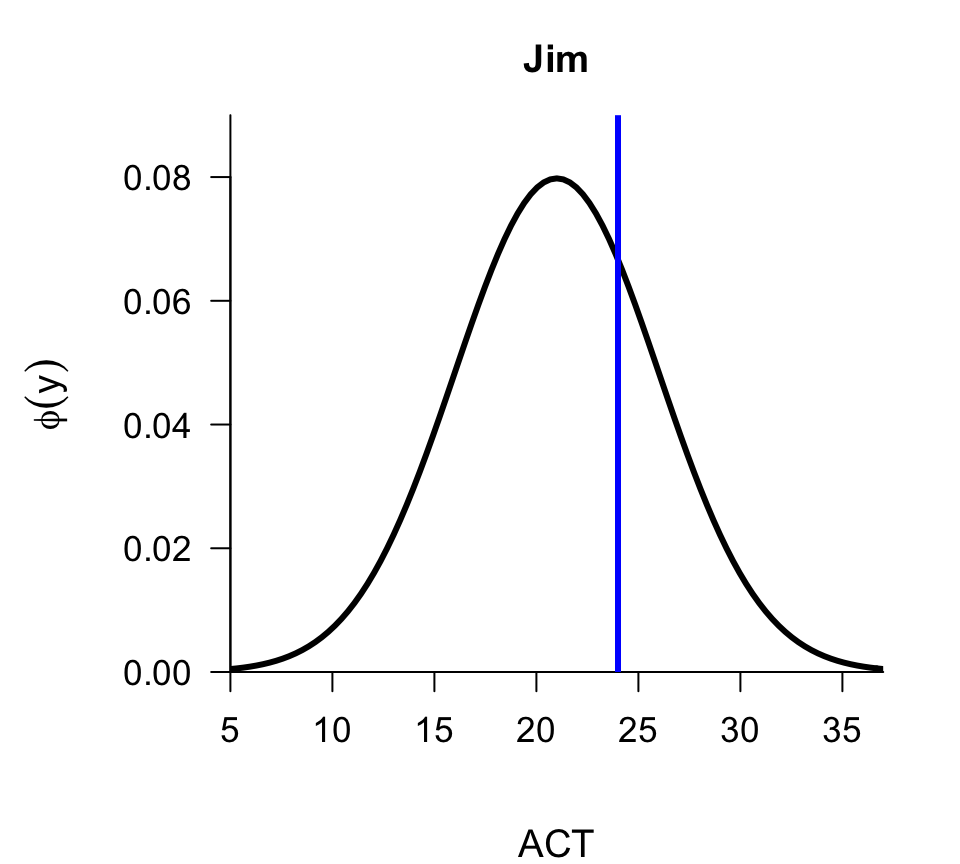

## Exemplo: SAT e ACT

Seja \(X\) uma v.a. representando a nota no SAT: \(X\sim N(\mu=1500,\sigma=300)\).

> Padronizando a v.a. das notas do SAT: \(Z_1=\frac{X-1500}{300}\sim N(0,1)\).

> Padronizando a nota da Pam: \(\frac{1800-1500}{300}=1\)

> Seja \(Y\) uma v.a. representando a nota no ACT: \(Y \sim N(\mu=21,\sigma=5)\).

> Padronizando a v.a. das notas do ACT: \(Z_2=\frac{Y-21}{5}\sim N(0,1)\).

> Padronizando a nota do Jim: \(\frac{24-21}{5}=0.6\)

## Exemplo: SAT e ACT

Com as notas padrozinadas, podemos compará-las:

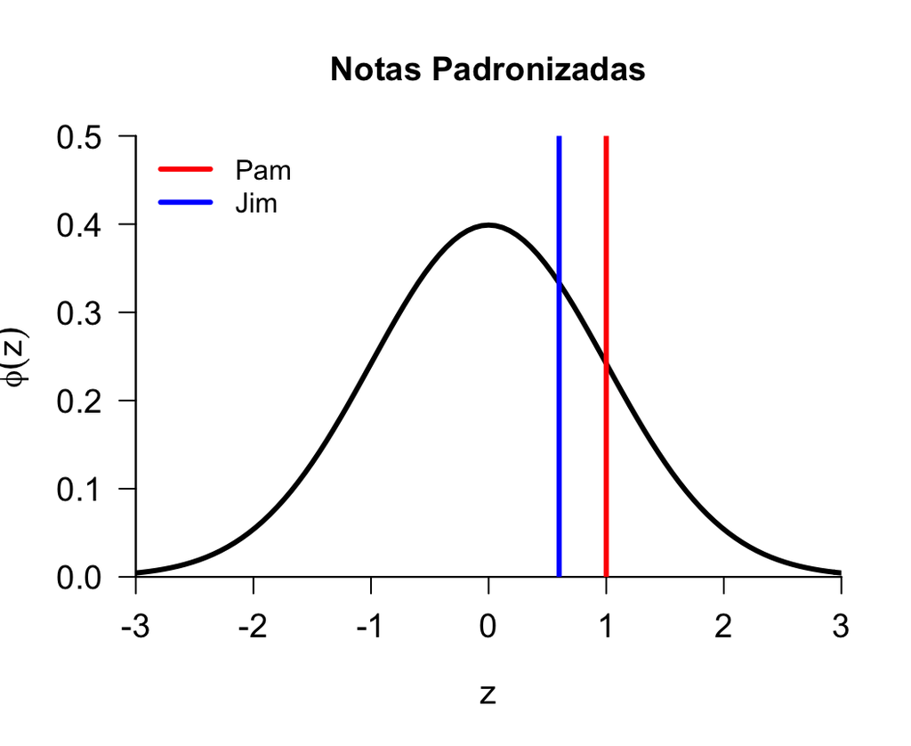

## Distribuição Normal

Para calcular as probabilidades, precisamos usar a f.d.a. de \(Z \sim N(0,1)\)

\[\Phi(t)=P(Z\leq t)=\int_{-\infty}^{t}\frac{1}{\sqrt{2\pi}}e^{-z^2/2}dz,\] que não tem forma fechada, pois \(e^{-z^2}\) não tem antiderivada.

> Contudo, os valores para \(Z \sim N(0,1)\) e \(\phi(z)\) encontram-se tabelados.

> Tudo o que precisamos fazer é transformar a variável em \(N(0,1)\) e usar os valores tabelados. Ou seja, para \(X \sim N(\mu, \sigma^{2})\), temos: \[F_X(a)=P(X \leq a)= P\left(\underbrace{\frac{X-\mu}{\sigma}}_{Z} \leq \frac{a-\mu}{\sigma}\right) = \Phi\left(\frac{a-\mu}{\sigma}\right)\]

## Distribuição Normal

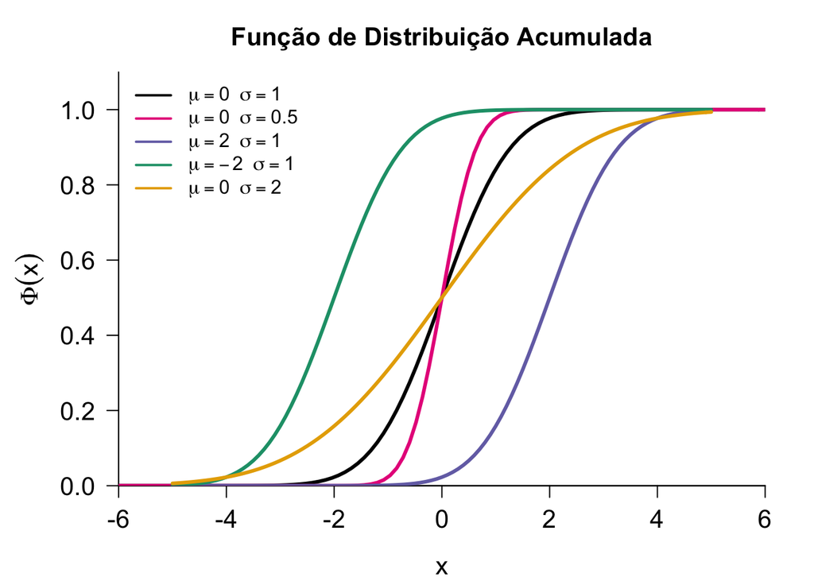

## Distribuição Normal - Simetria

A distribuição normal é simétrica, portanto \[P(Z<-z)=P(Z>z)\]

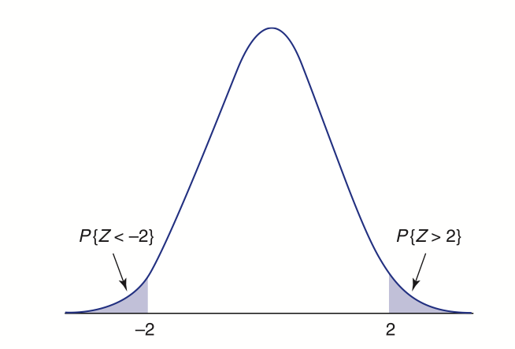

## Distribuição Normal

Seja \(Z\sim\mbox{Normal}(0,1)\), com f.d.a. \(\Phi\): \[\Phi(t)=P(Z\leq t)=\int_{-\infty}^{t}\frac{1}{\sqrt{2\pi}}e^{-z^2/2}dz\]

- \(\Phi(0)=0.5\)
- \(\Phi(-\infty)=0\)
- \(\Phi(\infty)=1\)
- Por simetria: \[\begin{aligned} \Phi(x) &= P(Z< x)= P(Z> -x) \\ &=1-P(Z<-x)=1-\Phi(-x) \end{aligned}\]

## Distribuição Normal

A probabilidade de um intervalo é dada por: \[ \begin{aligned} P(a<Z<b) &= P(Z<b)-P(Z<a) \\ &= P(Z \leq b) - P(Z \leq a) \\ &=\Phi(b)-\Phi(a) \end{aligned} \]

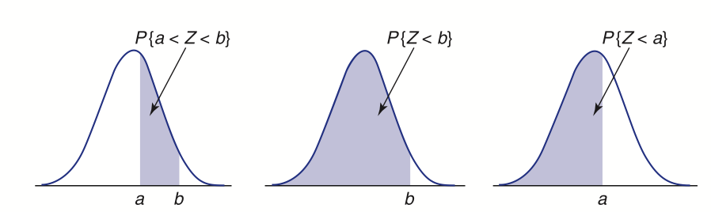

## Distribuição Normal

Exercitando com a tabela da Normal:

> \(\Phi(0.2)=0.5793\)

> \(\Phi(0.45)=0.6736\)

> \(\Phi(1.28)= 0.8997\)

> \(\begin{aligned} \Phi(-0.45) &= 1-\Phi(0.45) \\ & = 0.3264 \end{aligned}\)

## Distribuição Normal

**Exemplo**: Se \(X \sim N(10, 4)\), calcular:

1. \(P(8<X<10)\)
2. \(P(9 \leq X \leq 12)\)
3. \(P(X>10)\)
4. \(P(X<8 \mbox{ ou } X>11)\)

*Fonte: Morettin & Bussab*, Estatística Básica \(5^a\) edição, pág 182.

## Distribuição Normal

Recorde que se \(X \sim N(\mu, \sigma^2)\), então \(\frac{X-\mu}{\sigma} \sim N(0,1)\).

Neste problema, sabemos que \(\mu = 10\) e \(\sigma^2 = 4\), logo \(\sigma = 2\). Então \[Z=\frac{(X-10)}{2} \sim N(0,1)\]

Devemos transformar \(X\) de modo que o evento \(8<X<10\) permaneça inalterado. Fazemos isso transformando todos os lados da inequação:

\[\begin{aligned} 8<X<10 &\Leftrightarrow 8-10 < X-10 < 10-10 \\ & \Leftrightarrow \frac{8-10}{2} < \frac{X-10}{2} < \frac{10-10}{2} \\ &\Leftrightarrow -1 < Z < 0 \end{aligned} \]

## Distribuição Normal

Então, \(P(8 < X < 10) = P(-1 < Z < 0)\)

O valor \(\varPhi(0)\) está disponível na tabela e é igual a \(0.5\).

Para obtermos \(\varPhi(-1)\), devemos usar a simetria da função \(\varPhi\) em torno do zero: \[\varPhi(-x) = 1-\varPhi(x)\]

A tabela nos dá \(\varPhi(1) = 0.8413 \quad \rightarrow \quad \varPhi(-1) = 1-0.8413 = 0.1587\)

Concluimos portanto que \[ \begin{aligned} P(8<X<10) &= P(-1<Z<0) \\ &= \varPhi(0)-\varPhi(-1) \\ &= 0.5 - 0.1587 = 0.3413 \end{aligned} \]

## Distribuição Normal

Gráfico da curva \(N(10,4)\) com a região \([8,10]\) correspondente ao item 1 em destaque:

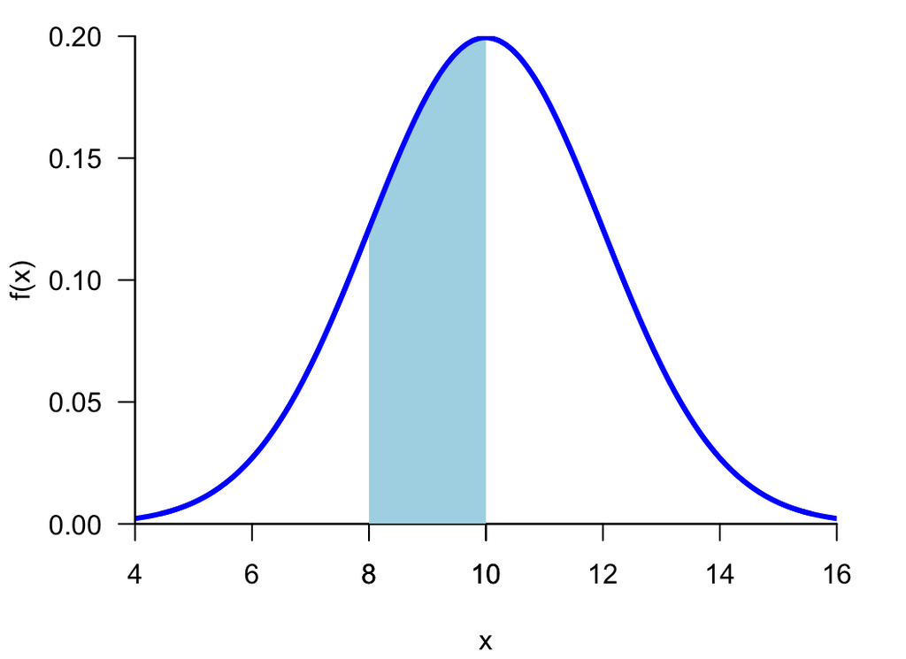

## Distribuição Normal

\(\begin{aligned} (2) \; P(9 \leq X \leq 12) & = P\left(\frac{9-10}{2} \leq \frac{X-10}{2} \leq \frac{12-10}{2}\right) \\ & = P(-1/2 \leq Z \leq 1) = 0.5328 \end{aligned}\)

\(\displaystyle (3) \; P(X>10) = P\left(\frac{X-10}{2} > \frac{10-10}{2}\right) = P(Z>0) = 0.5\)

\(\begin{aligned} (4) \; P(X < 8 \mbox{ ou } X > 11) & = P(X < 8) + P(X > 11) \\ &= P\left(\frac{X-10}{2} < \frac{8-10}{2}\right) + P\left(\frac{X-10}{2} > \frac{11-10}{2}\right) \\ &= P(Z<-1) + P(Z>1/2) \\ &= 0.1586 + 0.3085 = 0.4671 \end{aligned}\)

## Distribuição Normal

**Exemplo**: Se \(X \sim N(4,3^{2})\), calcule \(P(X \leq 7)\) e \(P(1 < X \leq 7)\).

\(\begin{aligned} F_X(7)= P(X \leq 7) &= P\left(\frac{X-4}{3} \leq \frac{7-4}{3}\right) \\ &= P(Z\leq 1)= \Phi(1)=0.8413 \end{aligned}\)

\(\begin{aligned} P(1 < X \leq 7) &= P\left(\frac{1-4}{3}<\frac{X-4}{3}\leq \frac{7-4}{3}\right) \\ &=P(-1<Z\leq 1) \\ &=\Phi(1)-\Phi(-1) \\ &=\Phi(1)-[1-\Phi(1)] \\ &=2\Phi(1)-1=2\times0.8413-1=0.6826 \end{aligned}\)

## Distribuição Normal

**Exemplo**: \(X \sim N(4,3^{2})\) e a região correspondente a \(P(1 < X \leq 7)\) em destaque no gráfico

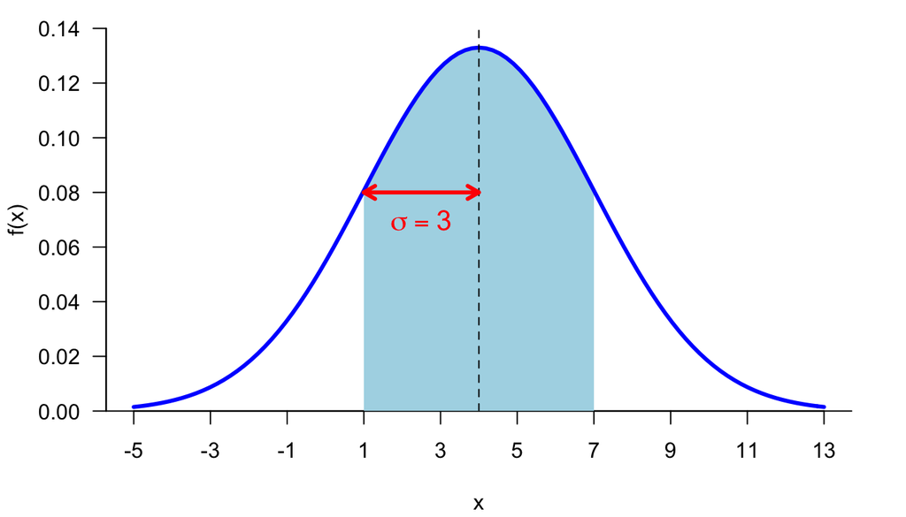

## Regra Empírica

Em uma distribuição normal \(X \sim N(\mu, \sigma^{2})\), temos o seguinte:

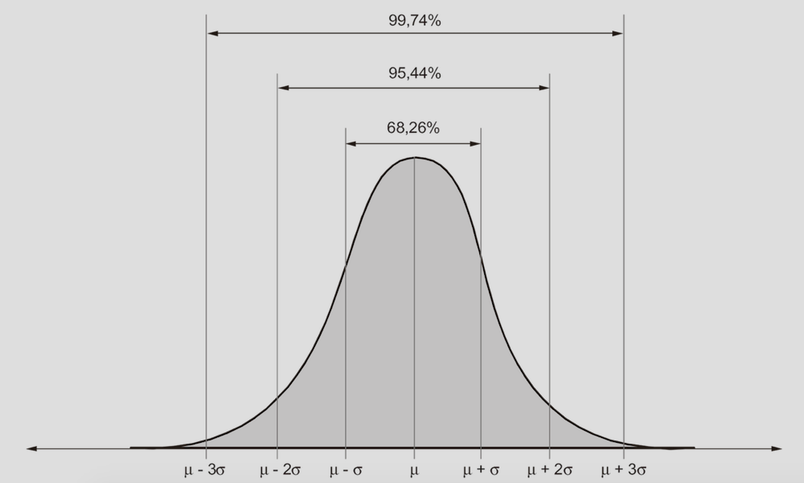

## Regra Empírica

[figure not shown]

**Exemplo:** Suponha que o \(QI\) da população mundial segue uma distribuição normal com média \(100\) e desvio padrão de \(15\)

Encontre um intervalo que englobe os \(QI\)’s de \(68.3\%\) da população?

E se quisermos \(95\%\)? E \(99.7\%\)?

## Regra Empírica

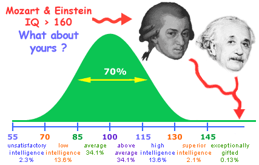

Como \(QI \sim N(100, 15)\), pela regra empírica:

\(68.3\%\) da população: \(85 \leq QI \leq 115\)

\(95\%\) da população: \(70 \leq QI \leq 130\)

\(99.7\%\) da população: \(55 \leq QI \leq 145\)

## Aproximação Normal para uma Binomial

Seja \(X \sim Bin(n, p)\)

O que acontece quando o número de ensaios \(n\) aumenta?

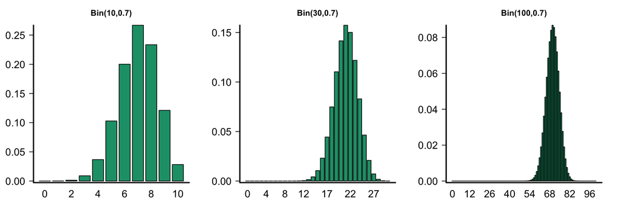

## Aproximação Normal para uma Binomial

Seja \(X \sim Bin(n, p)\). Se \(n\) é suficientemente grande, a distribuição de \(X\) pode ser aproximada pela distribuição normal, isto é,

> \[X \sim N(np, np(1-p))\]

> **Exemplo:** Se \(X \sim Bin(100, 0.7)\), podemos usar a aproximação \(X \sim N(70, 21)\)

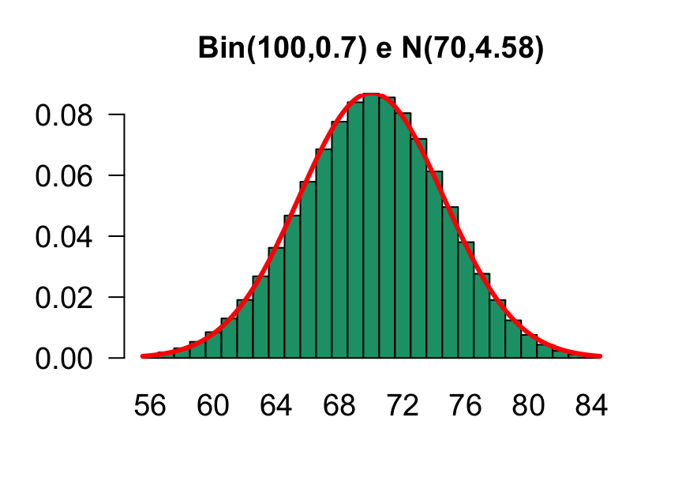

## Aproximação Normal para uma Binomial

**Exemplo:** Seja \(X\) o número de vezes que uma moeda honesta resulta em cara quando é lançada \(40\) vezes. Então \[X \sim Bin(40, 0.5)\]

Encontre \(P(X=20)\) usando a fórmula exata e a aproximação normal.

- Binomial

\[P(X=20) = {40 \choose 20}(0.5)^{20}(0.5)^{20} = 0.125\]

- Normal

\[P(X=20) \approx P(19.5 < X \leq 20.5) = 0.1256\]

## Aproximação Normal para uma Binomial

**Exemplo:** \(X \sim Bin(40, 0.5)\)

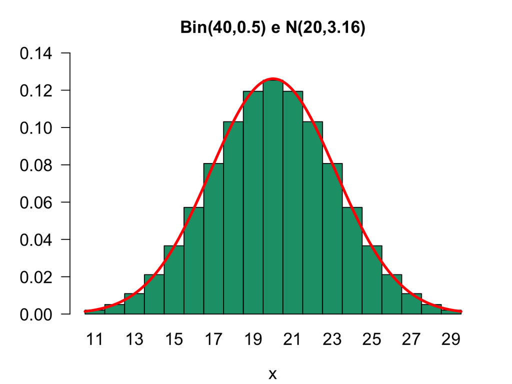

## Aproximação Normal para uma Binomial

Em geral, para que a aproximação para a normal seja utilizada:

\[np \geq 10\]

\[n (1-p) \geq 10\]

Ou seja, pelo menos 10 sucessos e pelo menos 10 fracassos na amostra.

## Relembrando: Propriedades da Esperança

1. Para qualquer v.a. \(X\) e constantes \(a\) e \(b\): \[\mathbb E(aX + b) = a \mathbb E(X) + b\]

   Casos particulares:
   - \(\mathbb E(X+b) = \mathbb E(X) + b\)
   - \(\mathbb E(aX) = a \mathbb E(X)\)
2. Se \(X_1, X_2, \ldots, X_n\) são variáveis aleatórias: \[ \mathbb E\left(\sum_{i=1}^n X_i \right) = \sum_{i=1}^n \mathbb E(X_i)\]

## Relembrando: Propriedades da Variância

1. Para qualquer v.a. \(X\) e constantes \(a\) e \(b\): \[Var(aX + b) = a^2Var(X)\]

   Casos particulares:
   - \(Var(X+b) = Var(X)\)
   - \(Var(aX) = a^2 Var(X)\)
2. Se \(X_1, X_2, \ldots, X_n\) são variáveis aleatórias independentes: \[ Var \left(\sum_{i=1}^n X_i \right) = \sum_{i=1}^n Var(X_i)\]

## Propriedades da Normal

Se adicionarmos ou multiplicarmos uma constante a uma v.a. com distribuição Normal, a v.a. resultante continua tendo distribuição normal. Ou seja,

\[X \sim N(\mu,\sigma^2) \qquad \Longrightarrow \qquad aX + b \sim N(a\mu + b, a^2\sigma^2).\]

Isso explica que: \[X \sim N(\mu,\sigma^2) \qquad \Longleftrightarrow \qquad Z=\frac{X-\mu}{\sigma}\sim N(0,1).\]

Se \(X\) e \(Y\) são v.a.'s independentes, tal que \(X \sim N(\mu_x,\sigma_x^2)\) e \(Y\sim N(\mu_y,\sigma_y^2),\) então \[X+Y\sim N(\mu_x+\mu_y,\sigma_x^2+\sigma_y^2)\]

## Distribuição Qui-quadrado

Se \(Z_1,Z_2,\ldots,Z_k\) são v.a. independentes e identicamente distribuídas (i.i.d.) \(N(0,1)\), temos que:

\[Q=\sum_{i=1}^kZ_i^2 \sim \chi_k^2\]

\(Q\) é uma v.a. com distribuição Qui-quadrado com \(k\) graus de liberdade.

Note que, se \(X_1,X_2,\ldots,X_n\) são v.a. i.i.d. \(N(\mu,\sigma^2)\), então:

\[Y=\sum_{i=1}^n\left(\frac{X_i-\bar{X}}{\sigma} \right)^2\sim \chi^2_{n-1}\]

## Distribuição Qui-quadrado

Uma v.a. \(X\) tem distribuição qui-quadrado com \(k\) graus de liberdade se sua f.d.p. é dada por:

\[f(x) = \frac{1}{2^{k/2}\Gamma(k/2)}\exp(-x/2)x^{k/2-1}\,, x\geq0\]

Note que: \(X\sim\chi^2_k\) é equivalente a dizer que \(X\sim Gama(k/2,1/2)\).

\(E(X)=k\) e \(Var(X)=2k\).

## Distribuição Qui-quadrado

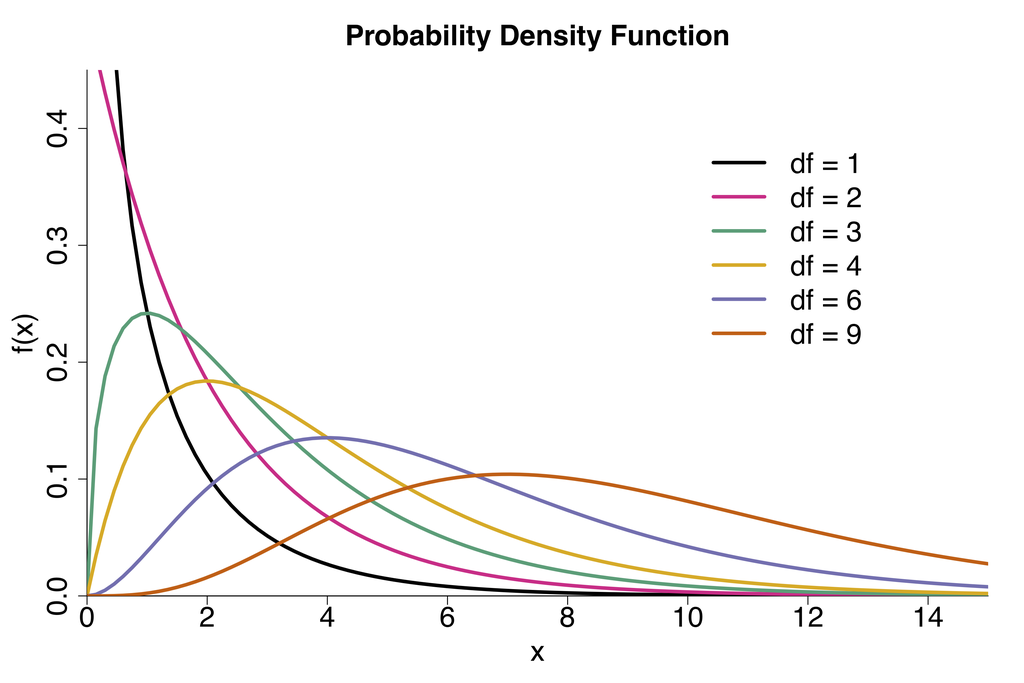

## Distribuição \(t\)

Seja \(Z \sim N(0,1)\) e \(V \sim \chi_k^2\) duas v.a. independentes, então

\[T=\frac{Z}{\sqrt{V/k}}\sim t_k\]

segue um distribuição \(t\) com \(k\) graus de liberdade.

Obs: Se comparada com a distribuição Normal, a \(t\) tem as caudas mais pesadas.

## Leituras

[figure not shown]

- Devore - capítulo 4.
- [Ross](http://www.sciencedirect.com/science/article/pii/B9780123743886000065): seções 6.3 a 6.7.
- [OpenIntro](https://www.openintro.org/stat/textbook.php): seções 3.1, 3.2, 3.4.2
- Magalhães: capítulo 6.

Slides produzidos pelos professores:

- Samara Kiihl
- Tatiana Benaglia
- Benilton Carvalho